# Access AIMS eReefs data with R

This tutorial is based on the article [How to open and work with NetCDF data in R](https://rpubs.com/boyerag/297592).

## Load the required R packages

First of all, load the necessary libraries.

```r
library(ncdf4) # package for netcdf manipulation
library(raster) # package for raster manipulation
library(ggplot2) # package for plotting
library(rgdal) # package for geospatial analysis
```

## Define which data to be plotted.

In this section we define which data we want to read and plot.

- **inputFile**  
  The netCDF input file. This can either be a downloaded file (see [How to manually download derived data from THREDDS](http://ereefs.aims.local/ereefs-aims/help/how-to-manually-download-derived-data)) or a OPeNDAP URL from the [AIMS THREDDS server](http://thredds.ereefs.aims.gov.au/thredds/catalog.html). For this tutorial we are using the OPeNDAP URL for the file “EREEFS_AIMS-CSIRO_gbr4_v2_hydro_daily-monthly-2010-09.nc”.
- **selectedVariable**  
  The name of the variable in the netCDF file.
- **selectedTimeIndex**  
  The time slice in the netCDF file. For example, in the netCDF file “EREEFS_AIMS-CSIRO_gbr4_v2_hydro_daily-monthly-2010-09.nc” the time steps are “days”. This means if you select `selectedTimeIndex=2` it refers to the second day in this file, which is 02/09/2010.
- **selectedDepthIndex**  
  The depth slice in the netCDF file. See the following table for a mapping of index to value:

  | Index (k) | Hydrodynamic 1km model | Hydrodynamic and BioGeoChemical 4km model |
  | --- | --- | --- |
  | 1 | -140.00 m | -145.00 m |
  | 2 | -120.00 m | -120.00 m |
  | 3 | -103.00 m | -103.00 m |
  | 4 | -88.00 m | -88.00 m |
  | 5 | -73.00 m | -73.00 m |
  | 6 | -60.00 m | -60.00 m |
  | 7 | -49.00 m | -49.00 m |
  | 8 | -39.50 m | -39.50 m |
  | 9 | -31.00 m | -31.00 m |
  | 10 | -24.00 m | -23.75 m |
  | 11 | -18.00 m | -17.75 m |
  | 12 | -13.00 m | -12.75 m |
  | 13 | -9.00 m | -8.80 m |
  | 14 | -5.25 m | -5.55 m |
  | 15 | -2.35 m | -3.00 m |
  | 16 | -0.50 m | -1.50 m |
  | 17 | n/a | -0.50 m |

```r
# OPeNDAP URL to file "EREEFS_AIMS-CSIRO_gbr4_v2_hydro_daily-monthly-2010-09.nc". Hydrodynamic 4km model, daily data for the month September 2010
input_file <- "http://thredds.ereefs.aims.gov.au/thredds/dodsC/s3://aims-ereefs-public-prod/derived/ncaggregate/ereefs/gbr4_v2/daily-monthly/EREEFS_AIMS-CSIRO_gbr4_v2_hydro_daily-monthly-2010-09.nc"
input_file
```

```
[1] "http://thredds.ereefs.aims.gov.au/thredds/dodsC/s3://aims-ereefs-public-prod/derived/ncaggregate/ereefs/gbr4_v2/daily-monthly/EREEFS_AIMS-CSIRO_gbr4_v2_hydro_daily-monthly-2010-09.nc"
```

```r
# The "temperature" variable
selectedVariable <- "temp"
selectedVariable
```

```
[1] "temp"
```

```r
# 2nd of September 2010
selectedTimeIndex <- 2
selectedTimeIndex
```

```
[1] 2
```

```r
# -1.50 m depth
selectedDepthIndex <- 16
selectedDepthIndex
```

```
[1] 16
```

## Read in the netCDF file contents

Read in the netCDF file contents and store the latitude, longitude, time and depth data in variables for later use.

```r
nc_data <- nc_open(input_file)

lon <- ncvar_get(nc_data, "longitude")
head(lon) # look at the first few entries in the longitude vector
```

```
[1] 142.1688 142.1988 142.2288 142.2588 142.2888 142.3188
```

```r
lat <- ncvar_get(nc_data, "latitude")
head(lat) # look at the first few entries in the latitude vector
```

```
[1] -28.69602 -28.66602 -28.63602 -28.60602 -28.57602 -28.54602
```

```r
time <- ncvar_get(nc_data, "time")
head(time) # look at the first few entries in the time vector
```

```
[1] 7548 7549 7550 7551 7552 7553
```

```r
depth <- ncvar_get(nc_data, "zc")
head(depth) # look at the first few entries in the depth vector
```

```
[1] -145 -120 -103  -88  -73  -60
```

Read in the data from the selected variable and select the time and depth slice.

```r
variableData.slice <- ncvar_get(nc = nc_data,
                                varid = selectedVariable,
                                start = c(1, 1, selectedDepthIndex, selectedTimeIndex),
                                count = c(length(lon), length(lat), 1, 1))
dim(variableData.slice)
```

```
[1] 491 723
```

Now that all data is stored in memory, close the netCDF file.

```r
nc_close(nc_data)
print("file closed")
```

```
[1] "file closed"
```

## Working with the data

Save the data in a raster. We also need to transpose and flip to orient the data correctly.

```r
r <- raster(t(variableData.slice), xmn = min(lon), xmx = max(lon), ymn = min(lat), ymx = max(lat), crs = CRS("+init=epsg:4326"))
r <- flip(r, direction = 'y')
dim(r)
```

```
[1] 723 491   1
```

## Plotting

Finally plot the data.

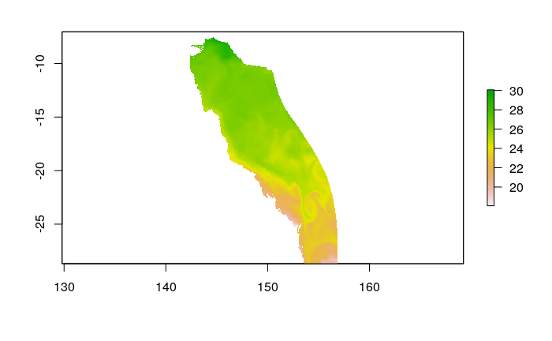

```r
plot(r)
```